# 第二次作业模板

- 请参照本模板结构和要求提交作业，至少满足模板中要求的部分，否则有扣分
- 作业内容中英文均可
- 作业主文件命名：“学号 姓名.ipynb"
- 作业相关文件命名（数据集等，如有）： “学号 姓名 文件1.xlsx"

# Assignment 2

满足的对应档次得分点：（说明自己做到了对应档次要求的哪几点，方便老师检查）

## 数据集介绍

如果是自己生成的，需要首先介绍自己生成数据集的方法、逻辑或流程，以及优点（加分点）

先介绍下数据集的领域，是什么业务，有多少数据量，然后进行字段详细介绍，自己未分析的字段可以不用介绍。

字段详细介绍：

如果是多个数据集则分别介绍，以及数据之间关联关系。

## 作业总体任务介绍

自己要做的是什么数据分析和研究，进行总体介绍。例如分析深圳市个人收入资产信用情况，分析某公司车贷情况等。

## 作业难点或挑战

列举作业中自己遇到的，或者主动给自己找的，并且成功克服了的难点或挑战（加分点）

## 作业详细内容

### 任务1

#### 任务描述

要做什么分析或工作，比如生成数据集，比如对比男女工资水平

#### 程序设计

这里写算法、注释、以及输出的表和图 关键的步骤可以给出较为详细的注释

```python
# Load Necessary Libraries
import matplotlib.pyplot as plt
import numpy as np
import pandas as pd
```

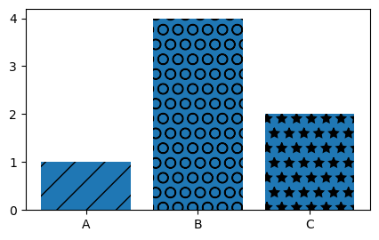

```python
labels = ['A', 'B', 'C']
values = [1,4,2]

plt.figure(figsize=(5,3), dpi=100)

bars = plt.bar(labels, values)

patterns = ['/', 'O', '*']
for bar in bars:
    bar.set_hatch(patterns.pop(0))

plt.savefig('barchart.png', dpi=300)

plt.show()
```

#### 分析结果

这里对输出的结果，图，表等进行解读，根据自己程序输出的结果，你得到了什么信息、发现或结论。如果无则不用写

## 任务2

结构和任务1一样。

## 作业及课程收获小结

可以是感悟，可以是常犯的语法错误，可以是程序设计或数据分析的逻辑设计等经验总结等。